# Palmetto Binary Logistic Regression (Task 1)

Lucas Boyd

1/28/2022

```r
knitr::opts_chunk$set(echo = TRUE, message = FALSE, warning = FALSE)
# attach packages
library(tidyverse)
library(here)
library(broom)
library(patchwork)
library(AICcmodavg)
library(caret)
library(kableExtra)
library(equatiomatic)
```

### Overview

The following report examines growth data of two dominant palmetto species (*Serenoa repens* and *Sabal etonia*) in South Florida to produce a binomial logistic regression model that classifies plant species based on several physical features of the plant. First, differences between the species are visualized to determine which variables will be useful in classifying species. Then, the model is evaluated using 10-fold cross validation and AIC. Finally, the model is applied to the data to determine its efficacy in predicting plant species.

**Data Citation:** Data source: Abrahamson, W.G. 2019. Survival, growth and biomass estimates of two dominant palmetto species of south-central Florida from 1981 - 2017, ongoing at 5-year intervals ver 1. Environmental Data Initiative. https://doi.org/10.6073/pasta/f2f96ec76fbbd4b9db431c79a770c4d5

### Reading in and cleaning up the data

```r
palmetto <- read_csv(here("data", "palmetto.csv")) %>%
  select(height, length, width, green_lvs, species) %>% # selecting for plant height (height), canopy length (length), canopy width (width), and number of green leaves (green_lvs)
# 1 = Serenoa repens, 2 = Sabal etonia
  drop_na() %>% # dropping NA values
  mutate(species_name = case_when(
    species == 1 ~ "Serenoa repens", # new column for species name
    species == 2 ~ "Sabal etonia"
  )) %>%
  mutate(species_name = as_factor(species_name)) # changing species name to a factor for use in blr
```

**Variables of interest:** - Number of green leaves - green_lvs

- Height of plant (cm) - height
- Width of canopy (cm) - width
- Length of canopy (cm) - length

### Visualizing differences between species

```r
# ggplots to visualize the differences in each variable between species
# effectplot could also be useful in these visualizations for blr

p1 <- ggplot(data = palmetto, aes(x = species_name, y = green_lvs, fill = species_name)) +
  geom_violin(scale = "count", color = "black") + # geom violin to visualize the large volume of data
geom_boxplot(color = "black", fill = NA, width = 0.1, outlier.color = NA) + # adding summary median and quartiles to figure
  stat_summary(fun=mean, # adding the mean to the figure
               geom="point",
               shape=20,
               size=4,
               color="black",
               fill="black") +
  scale_fill_manual(values = c("orange4", "darkolivegreen")) + # customizing colors
  theme_minimal(13) + # changing theme and font size
  theme(legend.position = "top",
        axis.text.x = element_blank(),
        legend.title = element_blank()) +
  labs(x = element_blank(), y = "Number of green leaves") # adding labels

# repeated above code for each variable in subsequent 3 plots, inserting different variables

p2 <- ggplot(data = palmetto, (aes(x = species_name, y = height, fill = species_name))) +
    geom_violin(scale = "count", color = "black") +
geom_boxplot(color = "black", fill = NA, width = 0.1, outlier.color = NA) +
  stat_summary(fun=mean,
               geom="point",
               shape=20,
               size=4,
               color="black",
               fill="black") +
  scale_fill_manual(values = c("orange4", "darkolivegreen")) +
  theme_minimal(13) +
  theme(legend.position = "none",
        axis.text.x = element_blank()) +
  labs(x = element_blank(), y = "Plant Height (cm)")

p3 <- ggplot(data = palmetto, (aes(x = species_name, y = width, fill = species_name))) +
    geom_violin(scale = "count", color = "black") +
geom_boxplot(color = "black", fill = NA, width = 0.1, outlier.color = NA) +
  stat_summary(fun=mean,
               geom="point",
               shape=20,
               size=4,
               color="black",
               fill="black") +
  scale_fill_manual(values = c("orange4", "darkolivegreen")) +
  theme_minimal(13) +
  theme(legend.position = "none",
        axis.text.x = element_blank()) +
  labs(x = element_blank(), y = "Canopy Width (cm)")

p4 <- ggplot(data = palmetto, (aes(x = species_name, y = length, fill = species_name))) +
    geom_violin(scale = "count", color = "black") +
geom_boxplot(color = "black", fill = NA, width = 0.1, outlier.color = NA) +
  stat_summary(fun=mean,
               geom="point",
               shape=20,
               size=4,
               color="black",
               fill="black") +
  scale_fill_manual(values = c("orange4", "darkolivegreen")) +
  theme_minimal(13) +
  theme(legend.position = "none",
        axis.text.x = element_blank()) +
  labs(x = element_blank(), y = "Canopy Length (cm)")
```

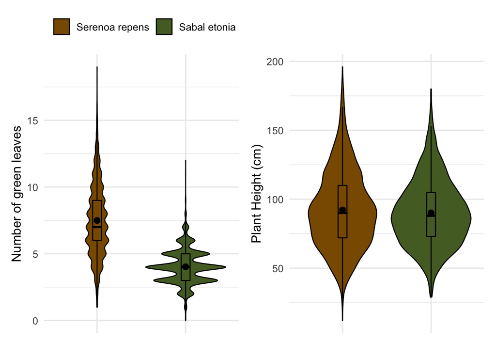

```r
(p1 | p2)
```

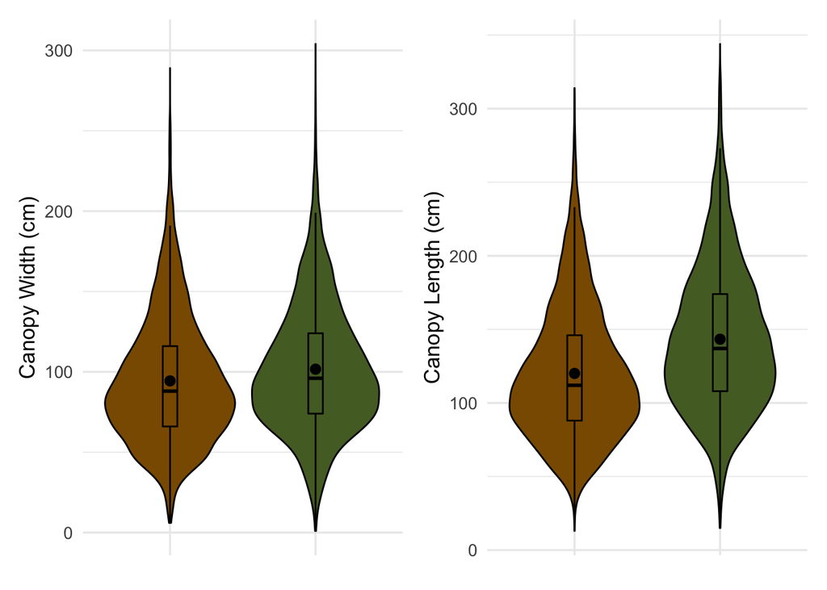

```r
(p3 | p4)
```

**Conclusion:** Based on this visualization, it appears that number of green leaves and canopy length will be useful in correctly classifying species, since there is a noticeable difference in the mean, median and overall spread of the data. Plant height and canopy width differ only very slightly between the two species, and thus will be less useful in classifying the species of plant.

### Binomial logistic regression

Running BLR for two models:

- **Model 1:** Plant species as a function of plant height, number of green leaves, canopy width and canopy length
- **Model 2:** Plant species as a function of plant height, number of green leaves, and canopy width

```r
# storing functions of combinations of variables for use in regression
f1 <- species_name ~ height + length + width + green_lvs
f2 <- species_name ~ height + width + green_lvs

# running and storing the regressions for each formula
blr1 <- glm(formula = f1,
            data = palmetto,
            family = "binomial")

blr2 <- glm(formula = f2,
            data = palmetto,
            family = "binomial")

# taking a look at the outputs of the regression with summary()
# reference (0) = Sabal etonia
```

### Model Selection

#### AIC

```r
aic <- aictab(list(blr1, blr2))
# model1 = 5194
# model2 = 5987
```

**Model 1:** 5194.6

**Model 2:** 5987.5

The difference in AICc is very large (792.9), thus model 1 has significantly better fit than model 2.

#### 10-fold cross validation

```r
set.seed(24) # setting seed for reproducibility

tr_ctrl <- trainControl(method = "repeatedcv", number = 10, repeats = 10) # stroing train control, specifying 10 folds

# train the model
model1 <- train(f1, data = palmetto,
                method = "glm",
                family = "binomial",
                trControl = tr_ctrl)
# accuracy = 0.917

# train the other model
model2 <- train(f2, data = palmetto,
                method = "glm",
                family = "binomial",
                trControl = tr_ctrl)
# accuracy = 0.899
```

**Model assessment results:** Model 1, which classifies palmetto species as a function of plant height, canopy width, canopy length and number of green leaves, performed better during 10-fold cross validation (accuracy = 91.7%, AICc = 5194.6) than model 2 (accuracy = 89.9%, AICc = 5987.5). Thus, based on the prediction accuracy results and AIC values, model 1 is preferred.

### Regression results

```r
# storing the results of regression as a data frame
blr1_tidy <- tidy(blr1) %>%
  mutate(p.value = case_when( # finalizing p.values for table
    p.value <0.001 ~ "<0.001"
  )) %>%
  mutate(term = case_when( # finalizing variable names for table
         term == "(Intercept)" ~ "Intercept",
         term == "height" ~ "Height",
         term == "length" ~ "Length",
         term == "width" ~ "Width",
         term == "green_lvs" ~ "# of green leaves")) %>%
  select(-statistic)

# finalizing table
kable(blr1_tidy,
      col.names = c("Term", "Coefficient", "Standard Error", "P Value"),
      digits = 3) %>%
  kable_minimal(full_width = FALSE)
```

| Term | Coefficient | Standard Error | P Value |
| --- | --- | --- | --- |
| Intercept | 3.227 | 0.142 | <0.001 |
| Height | -0.029 | 0.002 | <0.001 |
| Length | 0.046 | 0.002 | <0.001 |
| Width | 0.039 | 0.002 | <0.001 |
| # of green leaves | -1.908 | 0.039 | <0.001 |

**Final Model Equation**:
$$\begin{aligned}
\log\left[ \frac { \widehat{P( \operatorname{species\_name} = \operatorname{Sabal\ etonia} )} }{ 1 - \widehat{P( \operatorname{species\_name} = \operatorname{Sabal\ etonia} )} } \right] &= 3.23 - 0.03(\operatorname{height}) + 0.05(\operatorname{length}) + 0.04(\operatorname{width})\ - \\
&\quad 1.91(\operatorname{green\_lvs})
\end{aligned}$$

### Model success rate

```r
# storing a function for prediction accuracy
prediction_accuracy <- function(x, y) {
  accurate <- ifelse(x == y, 1, 0)
  return(accurate)
}

# creating a new dataframe with predictions based on our model
# could also use augment() here: palmetto_augment <- blr1 %>% augment(type.predict = "response")
palmetto_success <- palmetto %>%
  mutate(chances_sabal = predict(blr1, # adding a new column for the probability that the species is sabal, given our model
                   palmetto,
                   type = "response")) %>%
  mutate(predicted = ifelse(chances_sabal >= .50, "Sabal etonia", "Serenoa repens")) %>%  # adding a new column that predicts the species based on the probability, using 50% as the threshold
  mutate(accurate = prediction_accuracy(species_name, predicted))

# creating a final table for model prediction accuracy for each plant

accuracy_table <- palmetto_success %>%
  group_by(species_name) %>% # grouping by species
  summarize(observations = n(),
    total_accurate = sum(accurate), # finding total accurate predictions
            total_inaccurate = n() - sum(accurate), # total inaccurate predictions
            accuracy = (mean(accurate))*100,) # accuracy %

# finalized table with kable
kable(accuracy_table, digits = 1, col.names = c("Palmetto Species", "Total Observations", "Accurate", "Inaccurate", "% Accurate ")) %>%
  kable_minimal(full_width = FALSE)
```

| Palmetto Species | Total Observations | Accurate | Inaccurate | % Accurate |
| --- | --- | --- | --- | --- |
| Serenoa repens | 6112 | 5548 | 564 | 90.8 |
| Sabal etonia | 6155 | 5701 | 454 | 92.6 |

**Conclusion:** Model 1 (species as a function of plant height, canopy width, canopy length, and number of green leaves) is highly effective in classifying a plant as either *Sabal etonia* (92.6%, n = 6155) or Serenoa repens (90.8%, n = 6112).